# Customer Flow Forcast

## Aim

To build an intelligent system which can help Alibaba provide foot-traffic forecasting for those shops which uses Alibaba Point of Sales system.

## Objective

- Based on given foot-traffic for around 2000 stores and basic characteristics of these shops, we need to predict foot-traffic for coming 14 days.
- Current data is log based, we need summarize it on a per day and per shop basis
- Data is sparsely distributed, hence system should be designed to handle this type of data.
- Influence of external factors, like weather, which day of week, holidays, shopping festivals etc needs to be considered while predicting.

## Data Definition

Data is divided into 3 parts,

- **Shop Details**
- **User Visit logs**  
  This data defines physical presence of a user inside a given shop. This doesn't specify for how long was a user present inside the shop, it just logs the entry time.
- **User Purchase logs**  
  This data logs the time entry when a payment was made in shop and alibaba payment system was utilized

### Shop Details

```python
pd.read_sql_query("select * from shop_info limit 10", con = conn)
```

|  | shop_id | city_name | location_id | per_pay | score | comment_cnt | shop_level | cate_1_name | cate_2_name | cate_3_name |
| --- | --- | --- | --- | --- | --- | --- | --- | --- | --- | --- |
| 0 | 1 | 湖州 | 885 | 8 | 4.0 | 12.0 | 2 | 美食 | 休闲茶饮 | 饮品/甜点 |
| 1 | 2 | 哈尔滨 | 64 | 19 | NaN | NaN | 1 | 超市便利店 | 超市 | None |
| 2 | 3 | 南昌 | 774 | 5 | 3.0 | 2.0 | 0 | 美食 | 休闲茶饮 | 奶茶 |
| 3 | 4 | 天津 | 380 | 18 | NaN | NaN | 1 | 超市便利店 | 超市 | None |
| 4 | 5 | 杭州 | 263 | 2 | 2.0 | 2.0 | 0 | 美食 | 休闲食品 | 生鲜水果 |
| 5 | 6 | 大连 | 1139 | 13 | 3.0 | 1.0 | 0 | 美食 | 烘焙糕点 | 面包 |
| 6 | 7 | 绍兴 | 145 | 13 | 3.0 | 9.0 | 2 | 美食 | 快餐 | 西式快餐 |
| 7 | 8 | 杭州 | 234 | 16 | 3.0 | 1.0 | 0 | 美食 | 休闲食品 | 生鲜水果 |
| 8 | 9 | 杭州 | 1120 | 15 | 4.0 | 0.0 | 1 | 超市便利店 | 超市 | None |
| 9 | 10 | 孝感 | 98 | 10 | NaN | NaN | 0 | 超市便利店 | 超市 | None |

### User Visit logs

```python
pd.read_sql_query("select * from user_view limit 10", con = conn)
```

|  | user_id | shop_id | time_stamp |
| --- | --- | --- | --- |
| 0 | 13201967 | 1197 | 2016-10-21 18:00:00 |
| 1 | 19461365 | 1197 | 2016-06-28 23:00:00 |
| 2 | 15022321 | 1197 | 2016-07-16 19:00:00 |
| 3 | 5440872 | 1197 | 2016-07-15 07:00:00 |
| 4 | 12594529 | 1197 | 2016-08-07 16:00:00 |
| 5 | 5440872 | 1197 | 2016-08-12 08:00:00 |
| 6 | 19918044 | 1197 | 2016-09-03 16:00:00 |
| 7 | 9476039 | 1197 | 2016-09-04 17:00:00 |
| 8 | 4081995 | 1197 | 2016-09-25 10:00:00 |
| 9 | 12594529 | 1197 | 2016-08-07 16:00:00 |

### User Purchase logs

```python
pd.read_sql_query("select * from user_pay limit 10", con = conn)
```

|  | user_id | shop_id | time_stamp |
| --- | --- | --- | --- |
| 0 | 22127870 | 1862 | 2015-12-25 17:00:00 |
| 1 | 3434231 | 1862 | 2016-10-05 11:00:00 |
| 2 | 16955285 | 1862 | 2016-02-10 15:00:00 |
| 3 | 13799128 | 1862 | 2016-01-13 14:00:00 |
| 4 | 13799128 | 1862 | 2016-07-05 12:00:00 |
| 5 | 20244878 | 1862 | 2016-09-17 15:00:00 |
| 6 | 20244878 | 1862 | 2016-05-29 16:00:00 |
| 7 | 438444 | 1862 | 2016-02-22 17:00:00 |
| 8 | 22003193 | 1862 | 2016-08-07 15:00:00 |
| 9 | 20244878 | 1862 | 2016-04-17 16:00:00 |

```python
pd.read_sql_query(query1, conn)
```

|  | max(shop_id) | min(shop_id) | avg(shop_id) |
| --- | --- | --- | --- |
| 0 | 2000 | 1 | 1000.5 |

## Grouping foot traffic on daily basis

The "as is" data is an instance based time entry log of user activity, however, our final goal is to predict total expected user activity for a given day. Hence, we will summarize the current data to get total user activity for a given day, on a per shop basis.

### Data grouped based on daily user visit

```python
df_user_view
```

| shop_id | ts | total_view |
| --- | --- | --- |
| 1 | 2016-06-22 | 10 |
|  | 2016-06-23 | 18 |
|  | 2016-06-24 | 5 |
|  | 2016-06-25 | 22 |
|  | 2016-06-26 | 15 |
|  | 2016-06-27 | 12 |
|  | 2016-06-28 | 12 |
| ... | ... | ... |
| 2000 | 2016-10-25 | 14 |
|  | 2016-10-26 | 13 |
|  | 2016-10-27 | 16 |
|  | 2016-10-28 | 12 |
|  | 2016-10-29 | 11 |
|  | 2016-10-30 | 3 |
|  | 2016-10-31 | 15 |

150460 rows × 1 columns

### Data grouped based on User purchases

```python
df_user_pay
```

| shop_id | ts | total_pay |
| --- | --- | --- |
| 1 | 2015-10-10 | 188 |
|  | 2015-10-11 | 272 |
|  | 2015-10-12 | 257 |
|  | 2015-10-13 | 239 |
|  | 2015-10-14 | 277 |
|  | 2015-10-15 | 227 |
|  | 2015-10-16 | 242 |
| ... | ... | ... |
| 2000 | 2016-10-25 | 181 |
|  | 2016-10-26 | 184 |
|  | 2016-10-27 | 132 |
|  | 2016-10-28 | 133 |
|  | 2016-10-29 | 67 |
|  | 2016-10-30 | 67 |
|  | 2016-10-31 | 168 |

387133 rows × 1 columns

## Knowns and Unknowns

Let's brainstorm how to tackle the data

#### Knowns

- Daily total presence of user in a given shop
- Popularity of a given shop
- Category of a given shop
- Koibei.com's score of a given shop
- Publicaly available data - Weather, Public holidays, Day of week, Season ...

## Statistical Learning Approach

### Time Series Analysis

We will be performing TSA on a given store only. Below code picks up a store randomly and plots:

- Foot traffic trend
- Auto-Correlation
- Rolling Statistics
  - Min
  - Max
  - Mean
- ARMA forecast

```
Sample shop id for TSA:
772
                    total_today
shop_id ts
772     2016-07-01        119.0
        2016-07-02        109.0
        2016-07-03        113.0
        2016-07-04         92.0
        2016-07-05         72.0
        2016-07-06        102.0
        2016-07-07        120.0
...                         ...
2000    2016-10-25        195.0
        2016-10-26        197.0
        2016-10-27        148.0
        2016-10-28        145.0
        2016-10-29         78.0
        2016-10-30         70.0
        2016-10-31        183.0

[242969 rows x 1 columns]
count    242969.000000
mean        194.087600
std         146.074569
min           2.000000
25%         130.000000
50%         170.360212
75%         220.000000
max        5632.924439
Name: total_today, dtype: float64
```

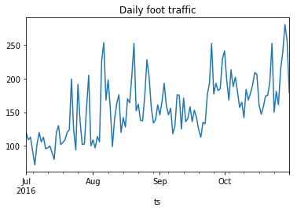

[figure not shown]

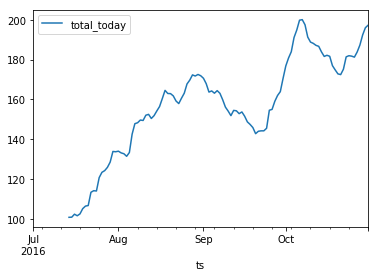

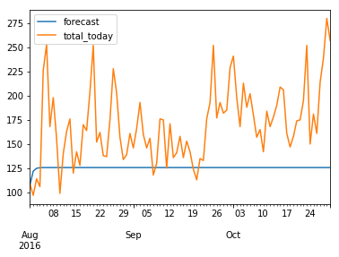

```python
shop_index = df_shop_ts.index.levels[0].get_values()
i = np.random.randint(low = 0, high = len(shop_index), size = 1) #shop_index.get_values()
shop_id = shop_index[i][0]
print("Sample shop id for TSA: " )
print(shop_id)

tsa(shop_id)
```

```
Sample shop id for TSA:
932
                    total_today
shop_id ts
932     2016-07-01         66.0
        2016-07-02         48.0
        2016-07-03         51.0
        2016-07-04         57.0
        2016-07-05         52.0
        2016-07-06         67.0
        2016-07-07         54.0
...                         ...
2000    2016-10-25        195.0
        2016-10-26        197.0
        2016-10-27        148.0
        2016-10-28        145.0
        2016-10-29         78.0
        2016-10-30         70.0
        2016-10-31        183.0

[212048 rows x 1 columns]
count    212048.000000
mean        194.143822
std         150.360848
min           2.000000
25%         129.324071
50%         170.324071
75%         218.324071
max        5633.292684
Name: total_today, dtype: float64
```

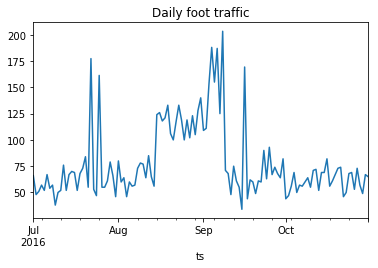

[figure not shown]

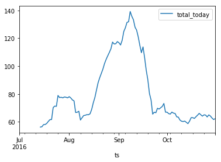

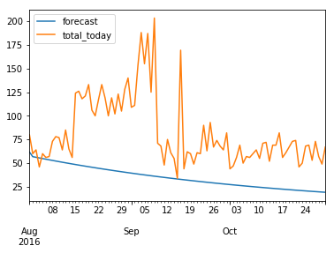

```python
shop_index = df_shop_ts.index.levels[0].get_values()
i = np.random.randint(low = 0, high = len(shop_index), size = 1) #shop_index.get_values()
shop_id = shop_index[i][0]
print("Sample shop id for TSA: " )
print(shop_id)

tsa(shop_id)
```